# Risk Factor Analysis

## Outcome Variable

**Outcome Variable:** y_rate_len

## Predictor Variables

**Intervention Variable:** pers_wast

**Adjustment Set:**

unadjusted

## Stratifying Variables

The analysis was stratified on these variable(s):

- agecat
- studyid
- country

## Data Summary

| agecat | studyid | country | pers_wast | n_cell | n |
| --- | --- | --- | --- | --- | --- |
| 0-3 months | ki0047075b-MAL-ED | BANGLADESH | 0 | 237 | 244 |
| 0-3 months | ki0047075b-MAL-ED | BANGLADESH | 1 | 7 | 244 |
| 0-3 months | ki1017093b-PROVIDE | BANGLADESH | 0 | 619 | 634 |
| 0-3 months | ki1017093b-PROVIDE | BANGLADESH | 1 | 15 | 634 |
| 0-3 months | ki1114097-CMIN | BANGLADESH | 0 | 41 | 43 |
| 0-3 months | ki1114097-CMIN | BANGLADESH | 1 | 2 | 43 |
| 0-3 months | ki0047075b-MAL-ED | BRAZIL | 0 | 180 | 180 |
| 0-3 months | ki1101329-Keneba | GAMBIA | 0 | 1246 | 1276 |
| 0-3 months | ki1101329-Keneba | GAMBIA | 1 | 30 | 1276 |
| 0-3 months | ki0047075b-MAL-ED | INDIA | 0 | 187 | 201 |
| 0-3 months | ki0047075b-MAL-ED | INDIA | 1 | 14 | 201 |
| 0-3 months | ki1000108-CMC-V-BCS-2002 | INDIA | 0 | 78 | 87 |
| 0-3 months | ki1000108-CMC-V-BCS-2002 | INDIA | 1 | 9 | 87 |
| 0-3 months | ki1000108-IRC | INDIA | 0 | 310 | 377 |
| 0-3 months | ki1000108-IRC | INDIA | 1 | 67 | 377 |
| 0-3 months | ki0047075b-MAL-ED | NEPAL | 0 | 172 | 175 |
| 0-3 months | ki0047075b-MAL-ED | NEPAL | 1 | 3 | 175 |
| 0-3 months | ki1000109-EE | PAKISTAN | 0 | 277 | 297 |
| 0-3 months | ki1000109-EE | PAKISTAN | 1 | 20 | 297 |
| 0-3 months | ki1000109-ResPak | PAKISTAN | 0 | 69 | 78 |
| 0-3 months | ki1000109-ResPak | PAKISTAN | 1 | 9 | 78 |
| 0-3 months | ki0047075b-MAL-ED | PERU | 0 | 271 | 271 |
| 0-3 months | ki1114097-CMIN | PERU | 0 | 89 | 93 |
| 0-3 months | ki1114097-CMIN | PERU | 1 | 4 | 93 |
| 0-3 months | ki1114097-CONTENT | PERU | 0 | 29 | 29 |
| 0-3 months | ki0047075b-MAL-ED | SOUTH AFRICA | 0 | 227 | 229 |
| 0-3 months | ki0047075b-MAL-ED | SOUTH AFRICA | 1 | 2 | 229 |
| 0-3 months | ki0047075b-MAL-ED | TANZANIA, UNITED REPUBLIC OF | 0 | 229 | 229 |
| 3-6 months | ki0047075b-MAL-ED | BANGLADESH | 0 | 226 | 231 |
| 3-6 months | ki0047075b-MAL-ED | BANGLADESH | 1 | 5 | 231 |

[output cut: 94 more lines]

The following strata were considered:

- agecat: 0-3 months, studyid: ki0047075b-MAL-ED, country: BANGLADESH
- agecat: 0-3 months, studyid: ki0047075b-MAL-ED, country: BRAZIL
- agecat: 0-3 months, studyid: ki0047075b-MAL-ED, country: INDIA
- agecat: 0-3 months, studyid: ki0047075b-MAL-ED, country: NEPAL
- agecat: 0-3 months, studyid: ki0047075b-MAL-ED, country: PERU
- agecat: 0-3 months, studyid: ki0047075b-MAL-ED, country: SOUTH AFRICA
- agecat: 0-3 months, studyid: ki0047075b-MAL-ED, country: TANZANIA, UNITED REPUBLIC OF
- agecat: 0-3 months, studyid: ki1000108-CMC-V-BCS-2002, country: INDIA
- agecat: 0-3 months, studyid: ki1000108-IRC, country: INDIA
- agecat: 0-3 months, studyid: ki1000109-EE, country: PAKISTAN
- agecat: 0-3 months, studyid: ki1000109-ResPak, country: PAKISTAN
- agecat: 0-3 months, studyid: ki1017093b-PROVIDE, country: BANGLADESH
- agecat: 0-3 months, studyid: ki1101329-Keneba, country: GAMBIA
- agecat: 0-3 months, studyid: ki1114097-CMIN, country: BANGLADESH
- agecat: 0-3 months, studyid: ki1114097-CMIN, country: PERU
- agecat: 0-3 months, studyid: ki1114097-CONTENT, country: PERU
- agecat: 12-24 months, studyid: ki0047075b-MAL-ED, country: BANGLADESH
- agecat: 12-24 months, studyid: ki0047075b-MAL-ED, country: BRAZIL
- agecat: 12-24 months, studyid: ki0047075b-MAL-ED, country: INDIA
- agecat: 12-24 months, studyid: ki0047075b-MAL-ED, country: NEPAL
- agecat: 12-24 months, studyid: ki0047075b-MAL-ED, country: PERU
- agecat: 12-24 months, studyid: ki0047075b-MAL-ED, country: SOUTH AFRICA
- agecat: 12-24 months, studyid: ki0047075b-MAL-ED, country: TANZANIA, UNITED REPUBLIC OF
- agecat: 12-24 months, studyid: ki1000108-CMC-V-BCS-2002, country: INDIA
- agecat: 12-24 months, studyid: ki1000108-IRC, country: INDIA
- agecat: 12-24 months, studyid: ki1017093b-PROVIDE, country: BANGLADESH
- agecat: 12-24 months, studyid: ki1066203-TanzaniaChild2, country: TANZANIA, UNITED REPUBLIC OF
- agecat: 12-24 months, studyid: ki1101329-Keneba, country: GAMBIA
- agecat: 12-24 months, studyid: ki1113344-GMS-Nepal, country: NEPAL
- agecat: 12-24 months, studyid: ki1114097-CMIN, country: BANGLADESH
- agecat: 12-24 months, studyid: ki1114097-CMIN, country: PERU
- agecat: 12-24 months, studyid: ki1114097-CONTENT, country: PERU
- agecat: 3-6 months, studyid: ki0047075b-MAL-ED, country: BANGLADESH
- agecat: 3-6 months, studyid: ki0047075b-MAL-ED, country: BRAZIL
- agecat: 3-6 months, studyid: ki0047075b-MAL-ED, country: INDIA
- agecat: 3-6 months, studyid: ki0047075b-MAL-ED, country: NEPAL
- agecat: 3-6 months, studyid: ki0047075b-MAL-ED, country: PERU
- agecat: 3-6 months, studyid: ki0047075b-MAL-ED, country: SOUTH AFRICA
- agecat: 3-6 months, studyid: ki0047075b-MAL-ED, country: TANZANIA, UNITED REPUBLIC OF
- agecat: 3-6 months, studyid: ki1000108-CMC-V-BCS-2002, country: INDIA
- agecat: 3-6 months, studyid: ki1000108-IRC, country: INDIA
- agecat: 3-6 months, studyid: ki1000109-EE, country: PAKISTAN
- agecat: 3-6 months, studyid: ki1000109-ResPak, country: PAKISTAN
- agecat: 3-6 months, studyid: ki1017093b-PROVIDE, country: BANGLADESH
- agecat: 3-6 months, studyid: ki1066203-TanzaniaChild2, country: TANZANIA, UNITED REPUBLIC OF
- agecat: 3-6 months, studyid: ki1101329-Keneba, country: GAMBIA
- agecat: 3-6 months, studyid: ki1113344-GMS-Nepal, country: NEPAL
- agecat: 3-6 months, studyid: ki1114097-CMIN, country: BANGLADESH
- agecat: 3-6 months, studyid: ki1114097-CMIN, country: PERU
- agecat: 3-6 months, studyid: ki1114097-CONTENT, country: PERU
- agecat: 6-12 months, studyid: ki0047075b-MAL-ED, country: BANGLADESH
- agecat: 6-12 months, studyid: ki0047075b-MAL-ED, country: BRAZIL
- agecat: 6-12 months, studyid: ki0047075b-MAL-ED, country: INDIA
- agecat: 6-12 months, studyid: ki0047075b-MAL-ED, country: NEPAL
- agecat: 6-12 months, studyid: ki0047075b-MAL-ED, country: PERU
- agecat: 6-12 months, studyid: ki0047075b-MAL-ED, country: SOUTH AFRICA
- agecat: 6-12 months, studyid: ki0047075b-MAL-ED, country: TANZANIA, UNITED REPUBLIC OF
- agecat: 6-12 months, studyid: ki1000108-CMC-V-BCS-2002, country: INDIA
- agecat: 6-12 months, studyid: ki1000108-IRC, country: INDIA
- agecat: 6-12 months, studyid: ki1000109-EE, country: PAKISTAN
- agecat: 6-12 months, studyid: ki1000109-ResPak, country: PAKISTAN
- agecat: 6-12 months, studyid: ki1017093b-PROVIDE, country: BANGLADESH
- agecat: 6-12 months, studyid: ki1066203-TanzaniaChild2, country: TANZANIA, UNITED REPUBLIC OF
- agecat: 6-12 months, studyid: ki1101329-Keneba, country: GAMBIA
- agecat: 6-12 months, studyid: ki1112895-Guatemala BSC, country: GUATEMALA
- agecat: 6-12 months, studyid: ki1113344-GMS-Nepal, country: NEPAL
- agecat: 6-12 months, studyid: ki1114097-CMIN, country: BANGLADESH
- agecat: 6-12 months, studyid: ki1114097-CMIN, country: PERU
- agecat: 6-12 months, studyid: ki1114097-CONTENT, country: PERU

## Methods Detail

We’re interested in the causal parameters $E[Y_a]$ for all values of $a \in \mathcal{A}$. These parameters represent the mean outcome if, possibly contrary to fact, we intervened to set all units to have $A=a$. Under the randomization and positivity assumptions, these are identified by the statistical parameters $\psi_a=E_W[E_{Y|A,W}(Y|A=a,W)]$. In addition, we’re interested in the mean of $Y$, $E[Y]$ under no intervention (the observed mean). We will estimate these parameters by using SuperLearner to fit the relevant likelihood factors – $E_{Y|A,W}(Y|A=a,W)$ and $p(A=a|W)$, and then updating our likelihood fit using a joint TMLE.

For unadjusted analyses ($W=\{\}$), initial likelihoods were estimated using Lrnr_glm to estimate the simple $E(Y|A)$ and Lrnr_mean to estimate $p(A)$. For adjusted analyses, a small library containing Lrnr_glmnet, Lrnr_xgboost, and Lrnr_mean was used.

Having estimated these parameters, we will then use the delta method to estimate relative risks and attributable risks relative to a prespecified baseline level of $A$.

[output not shown]

[output cut: 2237 more lines]

[output not shown]

# Results Detail

## Results Plots

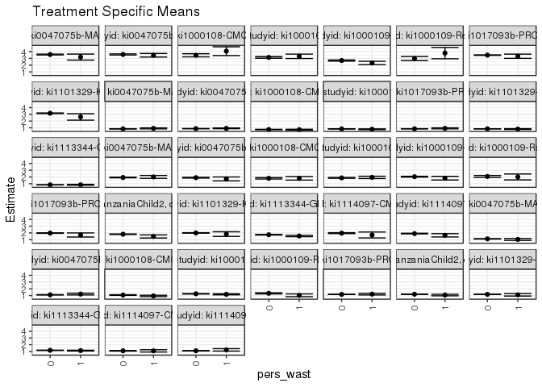

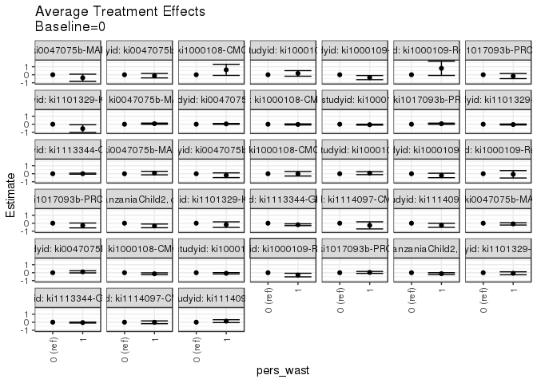

## Results Table

### Parameter: TSM

| agecat | studyid | country | intervention_level | baseline_level | estimate | ci_lower | ci_upper |
| --- | --- | --- | --- | --- | --- | --- | --- |
| 0-3 months | ki0047075b-MAL-ED | BANGLADESH | 0 | NA | 3.5743398 | 3.5115720 | 3.6371076 |
| 0-3 months | ki0047075b-MAL-ED | BANGLADESH | 1 | NA | 3.1945689 | 2.7473894 | 3.6417485 |
| 0-3 months | ki0047075b-MAL-ED | INDIA | 0 | NA | 3.5846997 | 3.5025087 | 3.6668906 |
| 0-3 months | ki0047075b-MAL-ED | INDIA | 1 | NA | 3.4662753 | 3.2034501 | 3.7291004 |
| 0-3 months | ki1000108-CMC-V-BCS-2002 | INDIA | 0 | NA | 3.4602273 | 3.2304210 | 3.6900337 |
| 0-3 months | ki1000108-CMC-V-BCS-2002 | INDIA | 1 | NA | 4.0721705 | 3.4180044 | 4.7263366 |
| 0-3 months | ki1000108-IRC | INDIA | 0 | NA | 3.1432524 | 3.0274135 | 3.2590914 |
| 0-3 months | ki1000108-IRC | INDIA | 1 | NA | 3.3101900 | 2.9810180 | 3.6393621 |
| 0-3 months | ki1000109-EE | PAKISTAN | 0 | NA | 2.6815977 | 2.5944292 | 2.7687661 |
| 0-3 months | ki1000109-EE | PAKISTAN | 1 | NA | 2.3247049 | 2.0805992 | 2.5688107 |
| 0-3 months | ki1000109-ResPak | PAKISTAN | 0 | NA | 2.9810265 | 2.6836484 | 3.2784045 |
| 0-3 months | ki1000109-ResPak | PAKISTAN | 1 | NA | 3.7856034 | 2.9456041 | 4.6256027 |
| 0-3 months | ki1017093b-PROVIDE | BANGLADESH | 0 | NA | 3.4866208 | 3.4472663 | 3.5259754 |
| 0-3 months | ki1017093b-PROVIDE | BANGLADESH | 1 | NA | 3.3196577 | 3.0060232 | 3.6332923 |
| 0-3 months | ki1101329-Keneba | GAMBIA | 0 | NA | 3.1569246 | 3.1098184 | 3.2040308 |
| 0-3 months | ki1101329-Keneba | GAMBIA | 1 | NA | 2.6092243 | 2.1317057 | 3.0867428 |
| 3-6 months | ki0047075b-MAL-ED | BANGLADESH | 0 | NA | 1.9262837 | 1.8761470 | 1.9764203 |
| 3-6 months | ki0047075b-MAL-ED | BANGLADESH | 1 | NA | 2.0077108 | 1.7934907 | 2.2219309 |
| 3-6 months | ki0047075b-MAL-ED | INDIA | 0 | NA | 1.8986872 | 1.8373733 | 1.9600011 |
| 3-6 months | ki0047075b-MAL-ED | INDIA | 1 | NA | 1.7083532 | 1.4181641 | 1.9985423 |
| 3-6 months | ki1000108-CMC-V-BCS-2002 | INDIA | 0 | NA | 1.8042856 | 1.6950585 | 1.9135128 |
| 3-6 months | ki1000108-CMC-V-BCS-2002 | INDIA | 1 | NA | 1.8008134 | 1.5392723 | 2.0623545 |
| 3-6 months | ki1000108-IRC | INDIA | 0 | NA | 1.8684459 | 1.8000473 | 1.9368446 |
| 3-6 months | ki1000108-IRC | INDIA | 1 | NA | 1.9398355 | 1.7696015 | 2.1100694 |
| 3-6 months | ki1000109-EE | PAKISTAN | 0 | NA | 2.0386065 | 1.9770992 | 2.1001139 |
| 3-6 months | ki1000109-EE | PAKISTAN | 1 | NA | 1.8206521 | 1.5492929 | 2.0920114 |
| 3-6 months | ki1000109-ResPak | PAKISTAN | 0 | NA | 2.0763702 | 1.9265908 | 2.2261497 |
| 3-6 months | ki1000109-ResPak | PAKISTAN | 1 | NA | 2.0041236 | 1.5656092 | 2.4426380 |
| 3-6 months | ki1017093b-PROVIDE | BANGLADESH | 0 | NA | 1.9722820 | 1.9373473 | 2.0072166 |
| 3-6 months | ki1017093b-PROVIDE | BANGLADESH | 1 | NA | 1.6919819 | 1.3867130 | 1.9972507 |
| 3-6 months | ki1066203-TanzaniaChild2 | TANZANIA, UNITED REPUBLIC OF | 0 | NA | 1.8049737 | 1.7687607 | 1.8411867 |
| 3-6 months | ki1066203-TanzaniaChild2 | TANZANIA, UNITED REPUBLIC OF | 1 | NA | 1.4713558 | 1.2415098 | 1.7012018 |
| 3-6 months | ki1101329-Keneba | GAMBIA | 0 | NA | 1.9979402 | 1.9586556 | 2.0372249 |
| 3-6 months | ki1101329-Keneba | GAMBIA | 1 | NA | 1.8224234 | 1.4783348 | 2.1665120 |
| 3-6 months | ki1113344-GMS-Nepal | NEPAL | 0 | NA | 1.7297510 | 1.6880867 | 1.7714153 |
| 3-6 months | ki1113344-GMS-Nepal | NEPAL | 1 | NA | 1.5412792 | 1.4383684 | 1.6441901 |
| 3-6 months | ki1114097-CMIN | BANGLADESH | 0 | NA | 1.9623847 | 1.8930298 | 2.0317395 |
| 3-6 months | ki1114097-CMIN | BANGLADESH | 1 | NA | 1.6934503 | 1.2562597 | 2.1306410 |
| 3-6 months | ki1114097-CMIN | PERU | 0 | NA | 1.8984779 | 1.8503539 | 1.9466018 |
| 3-6 months | ki1114097-CMIN | PERU | 1 | NA | 1.6408582 | 1.3954932 | 1.8862232 |
| 6-12 months | ki0047075b-MAL-ED | BANGLADESH | 0 | NA | 1.1163287 | 1.0912422 | 1.1414153 |
| 6-12 months | ki0047075b-MAL-ED | BANGLADESH | 1 | NA | 1.0311465 | 0.8899932 | 1.1722998 |
| 6-12 months | ki0047075b-MAL-ED | INDIA | 0 | NA | 1.1122840 | 1.0838196 | 1.1407484 |
| 6-12 months | ki0047075b-MAL-ED | INDIA | 1 | NA | 1.2214441 | 1.0925160 | 1.3503722 |
| 6-12 months | ki1000108-CMC-V-BCS-2002 | INDIA | 0 | NA | 1.0792562 | 1.0263999 | 1.1321124 |
| 6-12 months | ki1000108-CMC-V-BCS-2002 | INDIA | 1 | NA | 0.9444362 | 0.8404375 | 1.0484349 |
| 6-12 months | ki1000108-IRC | INDIA | 0 | NA | 1.2616221 | 1.2305850 | 1.2926592 |
| 6-12 months | ki1000108-IRC | INDIA | 1 | NA | 1.1859390 | 1.1066127 | 1.2652653 |
| 6-12 months | ki1000109-ResPak | PAKISTAN | 0 | NA | 1.3306603 | 1.2418385 | 1.4194820 |
| 6-12 months | ki1000109-ResPak | PAKISTAN | 1 | NA | 1.0357970 | 0.8325546 | 1.2390394 |
| 6-12 months | ki1017093b-PROVIDE | BANGLADESH | 0 | NA | 1.1723145 | 1.1548313 | 1.1897978 |
| 6-12 months | ki1017093b-PROVIDE | BANGLADESH | 1 | NA | 1.2114485 | 1.0911175 | 1.3317795 |
| 6-12 months | ki1066203-TanzaniaChild2 | TANZANIA, UNITED REPUBLIC OF | 0 | NA | 1.1992758 | 1.1774025 | 1.2211490 |
| 6-12 months | ki1066203-TanzaniaChild2 | TANZANIA, UNITED REPUBLIC OF | 1 | NA | 1.0790323 | 0.9629353 | 1.1951293 |
| 6-12 months | ki1101329-Keneba | GAMBIA | 0 | NA | 1.1818885 | 1.1633913 | 1.2003856 |
| 6-12 months | ki1101329-Keneba | GAMBIA | 1 | NA | 1.1081503 | 0.9258943 | 1.2904062 |
| 6-12 months | ki1113344-GMS-Nepal | NEPAL | 0 | NA | 1.1739215 | 1.1531356 | 1.1947074 |
| 6-12 months | ki1113344-GMS-Nepal | NEPAL | 1 | NA | 1.1267041 | 1.0686514 | 1.1847568 |
| 6-12 months | ki1114097-CMIN | BANGLADESH | 0 | NA | 1.1011538 | 1.0649424 | 1.1373652 |
| 6-12 months | ki1114097-CMIN | BANGLADESH | 1 | NA | 1.0889721 | 0.9186634 | 1.2592808 |
| 6-12 months | ki1114097-CMIN | PERU | 0 | NA | 1.1084654 | 1.0834501 | 1.1334807 |
| 6-12 months | ki1114097-CMIN | PERU | 1 | NA | 1.2399106 | 1.0624195 | 1.4174017 |
| 12-24 months | ki0047075b-MAL-ED | BANGLADESH | 0 | NA | 0.8439569 | 0.8276909 | 0.8602229 |
| 12-24 months | ki0047075b-MAL-ED | BANGLADESH | 1 | NA | 0.9132934 | 0.8427874 | 0.9837994 |
| 12-24 months | ki0047075b-MAL-ED | INDIA | 0 | NA | 0.8770025 | 0.8588451 | 0.8951598 |
| 12-24 months | ki0047075b-MAL-ED | INDIA | 1 | NA | 0.9191346 | 0.8650885 | 0.9731807 |
| 12-24 months | ki1000108-CMC-V-BCS-2002 | INDIA | 0 | NA | 0.7455843 | 0.7157079 | 0.7754606 |
| 12-24 months | ki1000108-CMC-V-BCS-2002 | INDIA | 1 | NA | 0.7226655 | 0.6623835 | 0.7829476 |
| 12-24 months | ki1000108-IRC | INDIA | 0 | NA | 0.8385286 | 0.8176902 | 0.8593671 |
| 12-24 months | ki1000108-IRC | INDIA | 1 | NA | 0.7850819 | 0.7332934 | 0.8368705 |
| 12-24 months | ki1017093b-PROVIDE | BANGLADESH | 0 | NA | 0.8560759 | 0.8439673 | 0.8681846 |
| 12-24 months | ki1017093b-PROVIDE | BANGLADESH | 1 | NA | 0.9175298 | 0.8403701 | 0.9946894 |
| 12-24 months | ki1101329-Keneba | GAMBIA | 0 | NA | 0.8465130 | 0.8355291 | 0.8574968 |
| 12-24 months | ki1101329-Keneba | GAMBIA | 1 | NA | 0.8124489 | 0.7542500 | 0.8706478 |
| 12-24 months | ki1113344-GMS-Nepal | NEPAL | 0 | NA | 0.8372784 | 0.8216840 | 0.8528727 |
| 12-24 months | ki1113344-GMS-Nepal | NEPAL | 1 | NA | 0.8427064 | 0.7818303 | 0.9035824 |

### Parameter: E(Y)

| agecat | studyid | country | intervention_level | baseline_level | estimate | ci_lower | ci_upper |
| --- | --- | --- | --- | --- | --- | --- | --- |
| 0-3 months | ki0047075b-MAL-ED | BANGLADESH | NA | NA | 3.5634447 | 3.5006347 | 3.6262547 |
| 0-3 months | ki0047075b-MAL-ED | INDIA | NA | NA | 3.5764512 | 3.4977133 | 3.6551891 |
| 0-3 months | ki1000108-CMC-V-BCS-2002 | INDIA | NA | NA | 3.5235318 | 3.3031217 | 3.7439420 |
| 0-3 months | ki1000108-IRC | INDIA | NA | NA | 3.1729204 | 3.0609523 | 3.2848884 |
| 0-3 months | ki1000109-EE | PAKISTAN | NA | NA | 2.6575645 | 2.5739973 | 2.7411317 |
| 0-3 months | ki1000109-ResPak | PAKISTAN | NA | NA | 3.0738623 | 2.7876913 | 3.3600332 |
| 0-3 months | ki1017093b-PROVIDE | BANGLADESH | NA | NA | 3.4826706 | 3.4434873 | 3.5218539 |
| 0-3 months | ki1101329-Keneba | GAMBIA | NA | NA | 3.1440476 | 3.0964801 | 3.1916152 |
| 3-6 months | ki0047075b-MAL-ED | BANGLADESH | NA | NA | 1.9280462 | 1.8787523 | 1.9773401 |
| 3-6 months | ki0047075b-MAL-ED | INDIA | NA | NA | 1.8837264 | 1.8224393 | 1.9450135 |
| 3-6 months | ki1000108-CMC-V-BCS-2002 | INDIA | NA | NA | 1.8037880 | 1.7029866 | 1.9045894 |
| 3-6 months | ki1000108-IRC | INDIA | NA | NA | 1.8806738 | 1.8168757 | 1.9444719 |
| 3-6 months | ki1000109-EE | PAKISTAN | NA | NA | 2.0241201 | 1.9636505 | 2.0845898 |
| 3-6 months | ki1000109-ResPak | PAKISTAN | NA | NA | 2.0694234 | 1.9275918 | 2.2112551 |
| 3-6 months | ki1017093b-PROVIDE | BANGLADESH | NA | NA | 1.9654454 | 1.9303798 | 2.0005110 |
| 3-6 months | ki1066203-TanzaniaChild2 | TANZANIA, UNITED REPUBLIC OF | NA | NA | 1.7957288 | 1.7598510 | 1.8316067 |
| 3-6 months | ki1101329-Keneba | GAMBIA | NA | NA | 1.9931660 | 1.9537919 | 2.0325400 |
| 3-6 months | ki1113344-GMS-Nepal | NEPAL | NA | NA | 1.7057418 | 1.6666784 | 1.7448052 |
| 3-6 months | ki1114097-CMIN | BANGLADESH | NA | NA | 1.9478477 | 1.8775639 | 2.0181315 |
| 3-6 months | ki1114097-CMIN | PERU | NA | NA | 1.8940471 | 1.8464513 | 1.9416429 |
| 6-12 months | ki0047075b-MAL-ED | BANGLADESH | NA | NA | 1.1143928 | 1.0896103 | 1.1391753 |
| 6-12 months | ki0047075b-MAL-ED | INDIA | NA | NA | 1.1210558 | 1.0926349 | 1.1494766 |
| 6-12 months | ki1000108-CMC-V-BCS-2002 | INDIA | NA | NA | 1.0595162 | 1.0116132 | 1.1074192 |
| 6-12 months | ki1000108-IRC | INDIA | NA | NA | 1.2485668 | 1.2193308 | 1.2778028 |
| 6-12 months | ki1000109-ResPak | PAKISTAN | NA | NA | 1.2964732 | 1.2129800 | 1.3799664 |
| 6-12 months | ki1017093b-PROVIDE | BANGLADESH | NA | NA | 1.1731762 | 1.1558671 | 1.1904853 |
| 6-12 months | ki1066203-TanzaniaChild2 | TANZANIA, UNITED REPUBLIC OF | NA | NA | 1.1960560 | 1.1745115 | 1.2176004 |
| 6-12 months | ki1101329-Keneba | GAMBIA | NA | NA | 1.1800762 | 1.1614756 | 1.1986767 |
| 6-12 months | ki1113344-GMS-Nepal | NEPAL | NA | NA | 1.1681560 | 1.1485303 | 1.1877817 |
| 6-12 months | ki1114097-CMIN | BANGLADESH | NA | NA | 1.1007081 | 1.0652677 | 1.1361485 |
| 6-12 months | ki1114097-CMIN | PERU | NA | NA | 1.1117791 | 1.0868951 | 1.1366632 |
| 12-24 months | ki0047075b-MAL-ED | BANGLADESH | NA | NA | 0.8459764 | 0.8299714 | 0.8619814 |
| 12-24 months | ki0047075b-MAL-ED | INDIA | NA | NA | 0.8803730 | 0.8630530 | 0.8976931 |
| 12-24 months | ki1000108-CMC-V-BCS-2002 | INDIA | NA | NA | 0.7419316 | 0.7150261 | 0.7688371 |
| 12-24 months | ki1000108-IRC | INDIA | NA | NA | 0.8294859 | 0.8099817 | 0.8489901 |
| 12-24 months | ki1017093b-PROVIDE | BANGLADESH | NA | NA | 0.8575519 | 0.8455586 | 0.8695452 |
| 12-24 months | ki1101329-Keneba | GAMBIA | NA | NA | 0.8455626 | 0.8347576 | 0.8563677 |
| 12-24 months | ki1113344-GMS-Nepal | NEPAL | NA | NA | 0.8378848 | 0.8224521 | 0.8533174 |

### Parameter: ATE

| agecat | studyid | country | intervention_level | baseline_level | estimate | ci_lower | ci_upper |
| --- | --- | --- | --- | --- | --- | --- | --- |
| 0-3 months | ki0047075b-MAL-ED | BANGLADESH | 0 | 0 | 0.0000000 | 0.0000000 | 0.0000000 |
| 0-3 months | ki0047075b-MAL-ED | BANGLADESH | 1 | 0 | -0.3797708 | -0.8313340 | 0.0717924 |
| 0-3 months | ki0047075b-MAL-ED | INDIA | 0 | 0 | 0.0000000 | 0.0000000 | 0.0000000 |
| 0-3 months | ki0047075b-MAL-ED | INDIA | 1 | 0 | -0.1184244 | -0.3938013 | 0.1569524 |
| 0-3 months | ki1000108-CMC-V-BCS-2002 | INDIA | 0 | 0 | 0.0000000 | 0.0000000 | 0.0000000 |
| 0-3 months | ki1000108-CMC-V-BCS-2002 | INDIA | 1 | 0 | 0.6119432 | -0.0814140 | 1.3053004 |
| 0-3 months | ki1000108-IRC | INDIA | 0 | 0 | 0.0000000 | 0.0000000 | 0.0000000 |
| 0-3 months | ki1000108-IRC | INDIA | 1 | 0 | 0.1669376 | -0.1820221 | 0.5158973 |
| 0-3 months | ki1000109-EE | PAKISTAN | 0 | 0 | 0.0000000 | 0.0000000 | 0.0000000 |
| 0-3 months | ki1000109-EE | PAKISTAN | 1 | 0 | -0.3568927 | -0.6160953 | -0.0976902 |
| 0-3 months | ki1000109-ResPak | PAKISTAN | 0 | 0 | 0.0000000 | 0.0000000 | 0.0000000 |
| 0-3 months | ki1000109-ResPak | PAKISTAN | 1 | 0 | 0.8045770 | -0.0865081 | 1.6956620 |
| 0-3 months | ki1017093b-PROVIDE | BANGLADESH | 0 | 0 | 0.0000000 | 0.0000000 | 0.0000000 |
| 0-3 months | ki1017093b-PROVIDE | BANGLADESH | 1 | 0 | -0.1669631 | -0.4830571 | 0.1491309 |
| 0-3 months | ki1101329-Keneba | GAMBIA | 0 | 0 | 0.0000000 | 0.0000000 | 0.0000000 |
| 0-3 months | ki1101329-Keneba | GAMBIA | 1 | 0 | -0.5477003 | -1.0275367 | -0.0678640 |
| 3-6 months | ki0047075b-MAL-ED | BANGLADESH | 0 | 0 | 0.0000000 | 0.0000000 | 0.0000000 |
| 3-6 months | ki0047075b-MAL-ED | BANGLADESH | 1 | 0 | 0.0814271 | -0.1385818 | 0.3014361 |
| 3-6 months | ki0047075b-MAL-ED | INDIA | 0 | 0 | 0.0000000 | 0.0000000 | 0.0000000 |
| 3-6 months | ki0047075b-MAL-ED | INDIA | 1 | 0 | -0.1903340 | -0.4869299 | 0.1062619 |
| 3-6 months | ki1000108-CMC-V-BCS-2002 | INDIA | 0 | 0 | 0.0000000 | 0.0000000 | 0.0000000 |
| 3-6 months | ki1000108-CMC-V-BCS-2002 | INDIA | 1 | 0 | -0.0034723 | -0.2869054 | 0.2799608 |
| 3-6 months | ki1000108-IRC | INDIA | 0 | 0 | 0.0000000 | 0.0000000 | 0.0000000 |
| 3-6 months | ki1000108-IRC | INDIA | 1 | 0 | 0.0713895 | -0.1120715 | 0.2548506 |
| 3-6 months | ki1000109-EE | PAKISTAN | 0 | 0 | 0.0000000 | 0.0000000 | 0.0000000 |
| 3-6 months | ki1000109-EE | PAKISTAN | 1 | 0 | -0.2179544 | -0.4961971 | 0.0602883 |
| 3-6 months | ki1000109-ResPak | PAKISTAN | 0 | 0 | 0.0000000 | 0.0000000 | 0.0000000 |
| 3-6 months | ki1000109-ResPak | PAKISTAN | 1 | 0 | -0.0722466 | -0.5356350 | 0.3911417 |
| 3-6 months | ki1017093b-PROVIDE | BANGLADESH | 0 | 0 | 0.0000000 | 0.0000000 | 0.0000000 |
| 3-6 months | ki1017093b-PROVIDE | BANGLADESH | 1 | 0 | -0.2803001 | -0.5875614 | 0.0269612 |
| 3-6 months | ki1066203-TanzaniaChild2 | TANZANIA, UNITED REPUBLIC OF | 0 | 0 | 0.0000000 | 0.0000000 | 0.0000000 |
| 3-6 months | ki1066203-TanzaniaChild2 | TANZANIA, UNITED REPUBLIC OF | 1 | 0 | -0.3336179 | -0.5662992 | -0.1009367 |
| 3-6 months | ki1101329-Keneba | GAMBIA | 0 | 0 | 0.0000000 | 0.0000000 | 0.0000000 |
| 3-6 months | ki1101329-Keneba | GAMBIA | 1 | 0 | -0.1755168 | -0.5218407 | 0.1708071 |
| 3-6 months | ki1113344-GMS-Nepal | NEPAL | 0 | 0 | 0.0000000 | 0.0000000 | 0.0000000 |
| 3-6 months | ki1113344-GMS-Nepal | NEPAL | 1 | 0 | -0.1884717 | -0.2994967 | -0.0774467 |
| 3-6 months | ki1114097-CMIN | BANGLADESH | 0 | 0 | 0.0000000 | 0.0000000 | 0.0000000 |
| 3-6 months | ki1114097-CMIN | BANGLADESH | 1 | 0 | -0.2689343 | -0.7115919 | 0.1737233 |
| 3-6 months | ki1114097-CMIN | PERU | 0 | 0 | 0.0000000 | 0.0000000 | 0.0000000 |
| 3-6 months | ki1114097-CMIN | PERU | 1 | 0 | -0.2576197 | -0.5076595 | -0.0075799 |
| 6-12 months | ki0047075b-MAL-ED | BANGLADESH | 0 | 0 | 0.0000000 | 0.0000000 | 0.0000000 |
| 6-12 months | ki0047075b-MAL-ED | BANGLADESH | 1 | 0 | -0.0851822 | -0.2285474 | 0.0581830 |
| 6-12 months | ki0047075b-MAL-ED | INDIA | 0 | 0 | 0.0000000 | 0.0000000 | 0.0000000 |
| 6-12 months | ki0047075b-MAL-ED | INDIA | 1 | 0 | 0.1091601 | -0.0228727 | 0.2411929 |
| 6-12 months | ki1000108-CMC-V-BCS-2002 | INDIA | 0 | 0 | 0.0000000 | 0.0000000 | 0.0000000 |
| 6-12 months | ki1000108-CMC-V-BCS-2002 | INDIA | 1 | 0 | -0.1348200 | -0.2514798 | -0.0181601 |
| 6-12 months | ki1000108-IRC | INDIA | 0 | 0 | 0.0000000 | 0.0000000 | 0.0000000 |
| 6-12 months | ki1000108-IRC | INDIA | 1 | 0 | -0.0756831 | -0.1608651 | 0.0094988 |
| 6-12 months | ki1000109-ResPak | PAKISTAN | 0 | 0 | 0.0000000 | 0.0000000 | 0.0000000 |
| 6-12 months | ki1000109-ResPak | PAKISTAN | 1 | 0 | -0.2948633 | -0.5166668 | -0.0730598 |
| 6-12 months | ki1017093b-PROVIDE | BANGLADESH | 0 | 0 | 0.0000000 | 0.0000000 | 0.0000000 |
| 6-12 months | ki1017093b-PROVIDE | BANGLADESH | 1 | 0 | 0.0391340 | -0.0824605 | 0.1607284 |
| 6-12 months | ki1066203-TanzaniaChild2 | TANZANIA, UNITED REPUBLIC OF | 0 | 0 | 0.0000000 | 0.0000000 | 0.0000000 |
| 6-12 months | ki1066203-TanzaniaChild2 | TANZANIA, UNITED REPUBLIC OF | 1 | 0 | -0.1202434 | -0.2383830 | -0.0021039 |
| 6-12 months | ki1101329-Keneba | GAMBIA | 0 | 0 | 0.0000000 | 0.0000000 | 0.0000000 |
| 6-12 months | ki1101329-Keneba | GAMBIA | 1 | 0 | -0.0737382 | -0.2569304 | 0.1094540 |
| 6-12 months | ki1113344-GMS-Nepal | NEPAL | 0 | 0 | 0.0000000 | 0.0000000 | 0.0000000 |
| 6-12 months | ki1113344-GMS-Nepal | NEPAL | 1 | 0 | -0.0472173 | -0.1088791 | 0.0144444 |
| 6-12 months | ki1114097-CMIN | BANGLADESH | 0 | 0 | 0.0000000 | 0.0000000 | 0.0000000 |
| 6-12 months | ki1114097-CMIN | BANGLADESH | 1 | 0 | -0.0121817 | -0.1862975 | 0.1619341 |
| 6-12 months | ki1114097-CMIN | PERU | 0 | 0 | 0.0000000 | 0.0000000 | 0.0000000 |
| 6-12 months | ki1114097-CMIN | PERU | 1 | 0 | 0.1314452 | -0.0478001 | 0.3106904 |
| 12-24 months | ki0047075b-MAL-ED | BANGLADESH | 0 | 0 | 0.0000000 | 0.0000000 | 0.0000000 |
| 12-24 months | ki0047075b-MAL-ED | BANGLADESH | 1 | 0 | 0.0693365 | -0.0030215 | 0.1416945 |
| 12-24 months | ki0047075b-MAL-ED | INDIA | 0 | 0 | 0.0000000 | 0.0000000 | 0.0000000 |
| 12-24 months | ki0047075b-MAL-ED | INDIA | 1 | 0 | 0.0421322 | -0.0148825 | 0.0991468 |
| 12-24 months | ki1000108-CMC-V-BCS-2002 | INDIA | 0 | 0 | 0.0000000 | 0.0000000 | 0.0000000 |
| 12-24 months | ki1000108-CMC-V-BCS-2002 | INDIA | 1 | 0 | -0.0229187 | -0.0901982 | 0.0443607 |
| 12-24 months | ki1000108-IRC | INDIA | 0 | 0 | 0.0000000 | 0.0000000 | 0.0000000 |
| 12-24 months | ki1000108-IRC | INDIA | 1 | 0 | -0.0534467 | -0.1092705 | 0.0023771 |
| 12-24 months | ki1017093b-PROVIDE | BANGLADESH | 0 | 0 | 0.0000000 | 0.0000000 | 0.0000000 |
| 12-24 months | ki1017093b-PROVIDE | BANGLADESH | 1 | 0 | 0.0614538 | -0.0166501 | 0.1395578 |
| 12-24 months | ki1101329-Keneba | GAMBIA | 0 | 0 | 0.0000000 | 0.0000000 | 0.0000000 |
| 12-24 months | ki1101329-Keneba | GAMBIA | 1 | 0 | -0.0340641 | -0.0932904 | 0.0251622 |
| 12-24 months | ki1113344-GMS-Nepal | NEPAL | 0 | 0 | 0.0000000 | 0.0000000 | 0.0000000 |
| 12-24 months | ki1113344-GMS-Nepal | NEPAL | 1 | 0 | 0.0054280 | -0.0574137 | 0.0682696 |